# KIM DONGWON HOMEWORK 3

KIM DONGWON

2020 4 21

## R Markdown

##예제1 현재 주어진 자료는 일정 기간동안 지역 내의 모든 부동산 거래를 기록한 자료이므로 일종의 모집단이라고 생각할 수 있다. SalePrice 변수에 대해 히스토그램을 그려보고 수치적 요약값을 구해보자. 모집단의 분포는 어떠한가?

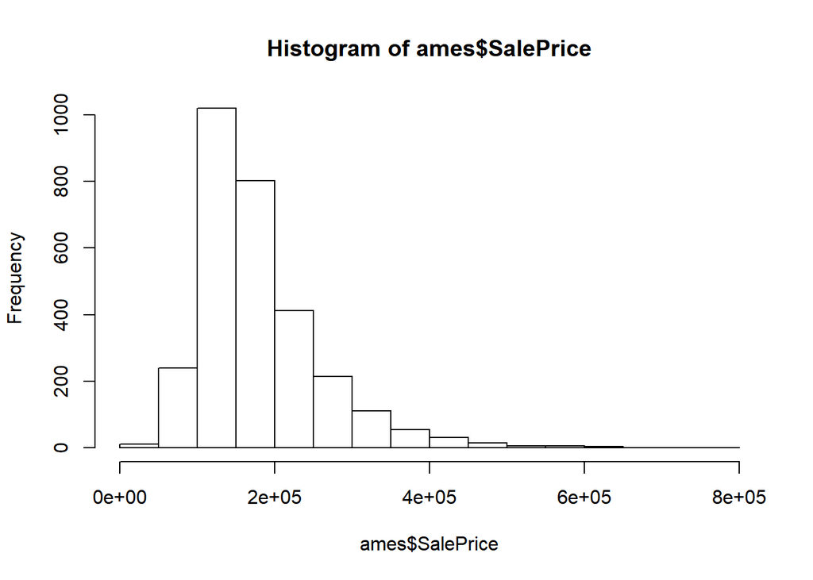

```r
ames<-read.csv("C:/Users/r english/Desktop/r/ames.csv",header = T)
hist(ames$SalePrice)
```

```r
summary(ames$SalePrice)
```

```
##    Min. 1st Qu.  Median    Mean 3rd Qu.    Max.
##   12789  129500  160000  180796  213500  755000
```

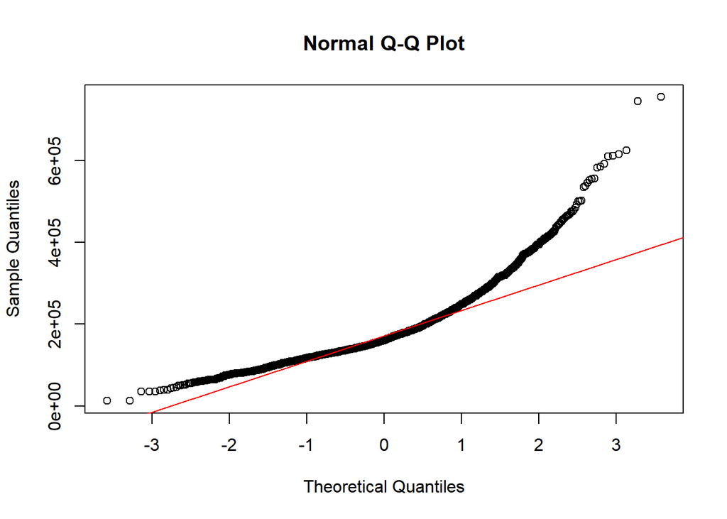

```r
qqnorm(ames$SalePrice)
qqline(ames$SalePrice,col=2)
```

히스토그램에서 살펴볼 때 right-skewed한 모습을 보이고있다.정규분포 분위수 대조도를 보았을 때도 점들이 직선주위에 밀집하다고는 말하기 어려운 형태를 보이고 있다.

##예제 2 이 지역에서 발생한 전체 부동산 거래 가격의 평균값을 추정해보려고 한다. 지금처럼 모집단 전체를 알게 되는 경우는 매우 드물기 때문에 대부분의 경우에는 모집단의 부분집합인 표본을 선택하여 모수를 추정하게 된다. SalePrice에서 50개의 랜덤 표본을 선택해보자. 이 때, 모평균의 추정값은 무엇인가?

```r
sale<- sample(ames$SalePrice, size = 50)
mean(sale)
```

```
## [1] 188779
```

##예제3 예제 2 의 과정을 5000 번 반복하여 표본 평균의 표본 분포를 구해보자. 즉, 크기가 50 인 랜덤 표본을 선택하여 표본평균을 구하는 과정을 5000 번 반복하고 이 결과를 sample_mean50 이라는 이름의 벡터에 저장을 한다. sample_mean50 을 이용하여 히스토 그램을 sample_mean50 그려보자. 표본 평균의 분포는 어떠한가?

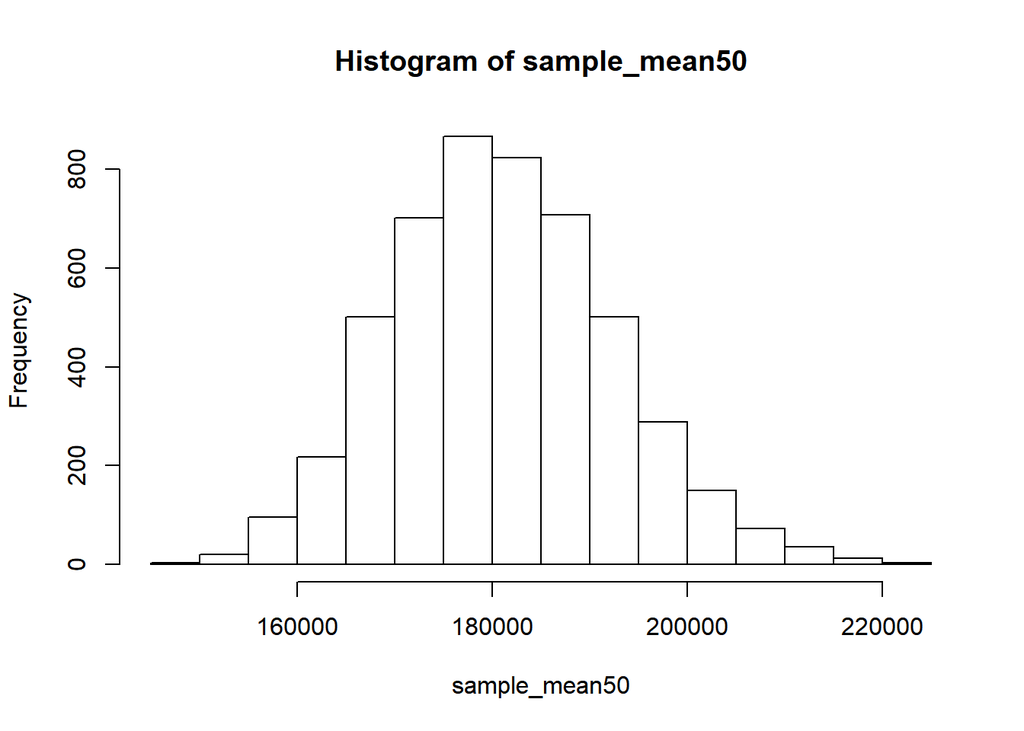

```r
sample_mean50<-c()
for(i in 1:5000){x<-sample(ames$SalePrice, size = 50)
sample_mean50[i] <- mean(x)}
hist(sample_mean50)
```

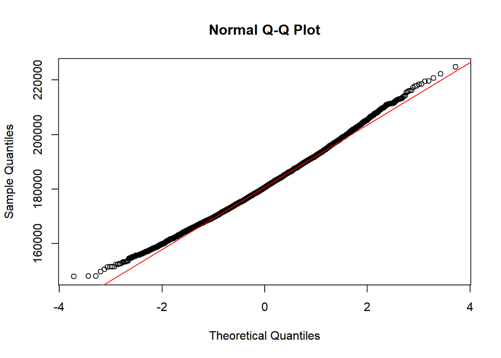

```r
qqnorm(sample_mean50)
qqline(sample_mean50,col=2)
```

히스토그램에서 표본평균의 분포는 정규분포에 근사함을 알 수 있다. 정규분포 분위수 대조도를 살펴보았을 때도 점들이 직선 위에 밀집하여 나타나고 있다 말할 수 있다.

##예제4 예제 3 의 sample_mean50 의 평균과 분산을 계산해보자. sample_mean50 의 평균 값은 모집단의 평균과 어떠한 관계가 있는가? sample_mean50 의 분산값은 모분산과 어떠 한 관계가 있는가?

```r
mean(sample_mean50)
```

```
## [1] 181079.8
```

```r
mean(ames$SalePrice)
```

```
## [1] 180796.1
```

```r
var(sample_mean50)
```

```
## [1] 128578767
```

```r
var(ames$SalePrice)
```

```
## [1] 6381883616
```

```r
 var(ames$SalePrice)/50
```

```
## [1] 127637672
```

모집단의 분포가 정규분포가 아니므로 중심극한정리에서 이 문제를 생각해 볼 수 있는데 모평균은 근사적으로 표본평균과 값이 같고 표본분산은 모분산에서 표본의 크기만큼 나눈 값인데, 위에 코드를 입력하면 이러한 관계를 확인해볼 수 있다.

##예제5 예제 3 의 과정을 표본의 크기를 150 으로 증가시켜 반복해보자. 이 결과는 sample_mean150 에 저장한다. 표본의 크기에 따른 표본 평균의 분포는 어떠한가?

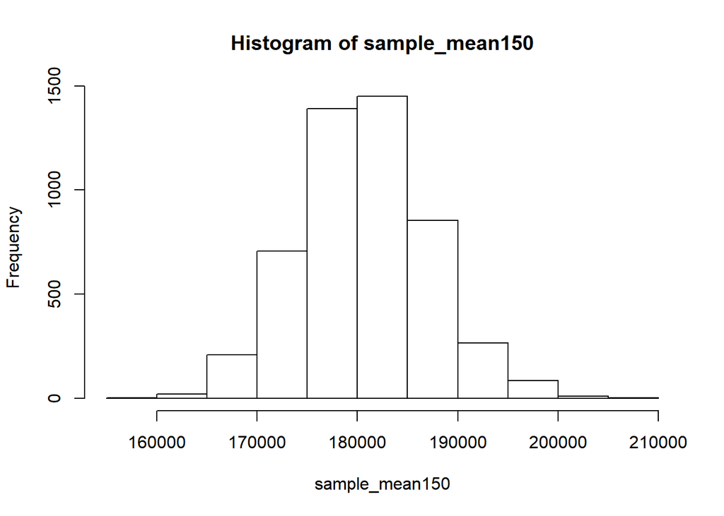

```r
sample_mean150<-c()
for(j in 1:5000){x<-sample(ames$SalePrice, size = 150)
sample_mean150[j] <- mean(x)}
hist(sample_mean150)
```

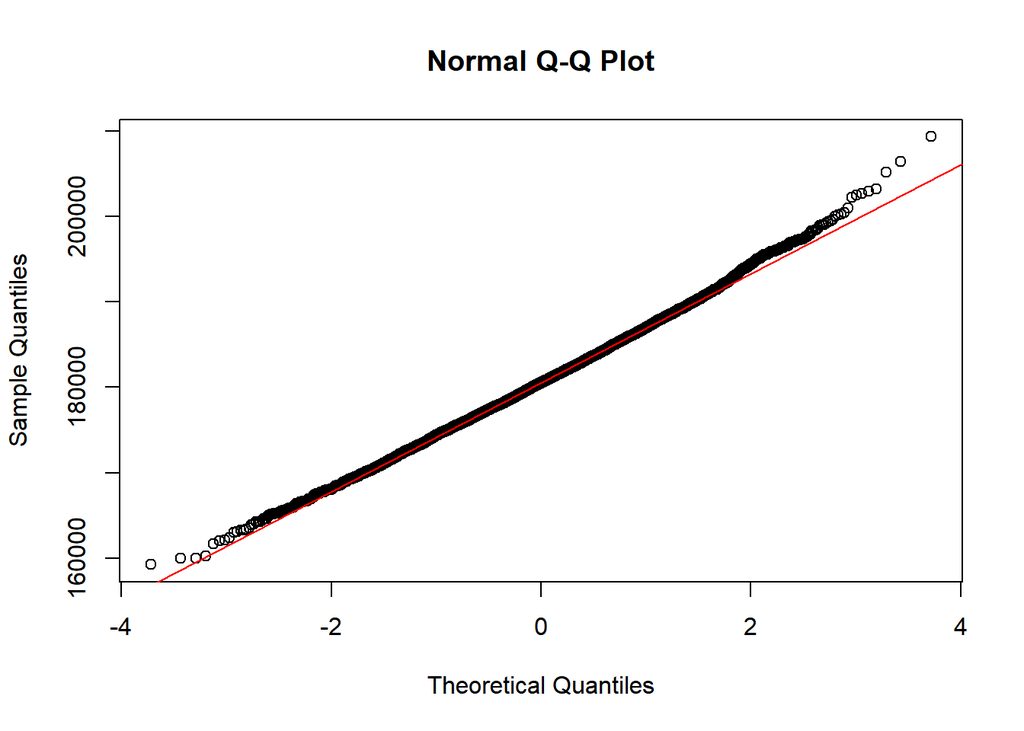

```r
qqnorm(sample_mean150)
qqline(sample_mean150,col=2)
```

표본평균의 분포를 비교해 보았을 때, 표본 크기가 클수록 표본평균의 분산이 작음을 히스토그램의 가로축을 통해 알 수 있다. 정규분포 분위수 대조도에서도 세로축을 통해 이를 확인할 수 있다.

##예제6 ames 자료를 이용해서 다음 문제들을 풀도록 한다. 6-1. Yr.sold 변수는 부동산 거래가 이뤄진 년도를 의미하는 변수이다. 이 변수를 이용하여 각 연도별 평균 거래가격(SalePrice)의 변화를 그래프로 나타내보자.(plot 함수를 이용할 것) 어느 해의 거래가격이 가장 높았는가?

```r
View(ames)

sam1<-ames[ames$Yr.Sold == 2006,]
sam_sale1<-sam1$SalePrice
mean(sam_sale1)
```

```
## [1] 181761.6
```

```r
sam2<-ames[ames$Yr.Sold == 2007,]
sam_sale2<-sam2$SalePrice
mean(sam_sale2)
```

```
## [1] 185138.2
```

```r
sam3<-ames[ames$Yr.Sold == 2008,]
sam_sale3<-sam3$SalePrice
mean(sam_sale3)
```

```
## [1] 178841.8
```

```r
sam4<-ames[ames$Yr.Sold == 2009,]
sam_sale4<-sam4$SalePrice
mean(sam_sale4)
```

```
## [1] 181404.6
```

```r
sam5<-ames[ames$Yr.Sold == 2010,]
sam_sale5<-sam5$SalePrice
mean(sam_sale5)
```

```
## [1] 172597.6
```

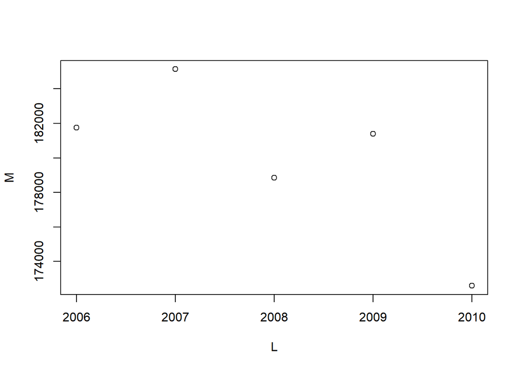

```r
L<-c(2006,2007,2008,2009,2010)
M<-c(mean(sam_sale1),mean(sam_sale2),mean(sam_sale3),mean(sam_sale4),mean(sam_sale5))
plot(L,M)
```

2007년의 평균거래가격이 가장 높았다.

6-2. 위의 연도별 데이터 중에 2009년도 데이터만 사용하겠다고 하자. Mo.solde 변수를 이용해 2009년도 데이터를 분기별 (1분기: 1-3월, 2분기: 4-6월, 3분기: 79월, 4분기: 10-12월) 로 나누도록 한다. 각 분기별 거래가격(SalePrice)에 대한 히스토그램을 그려보자. 각 분기별로 거래가격의 분포가 달라지는가?

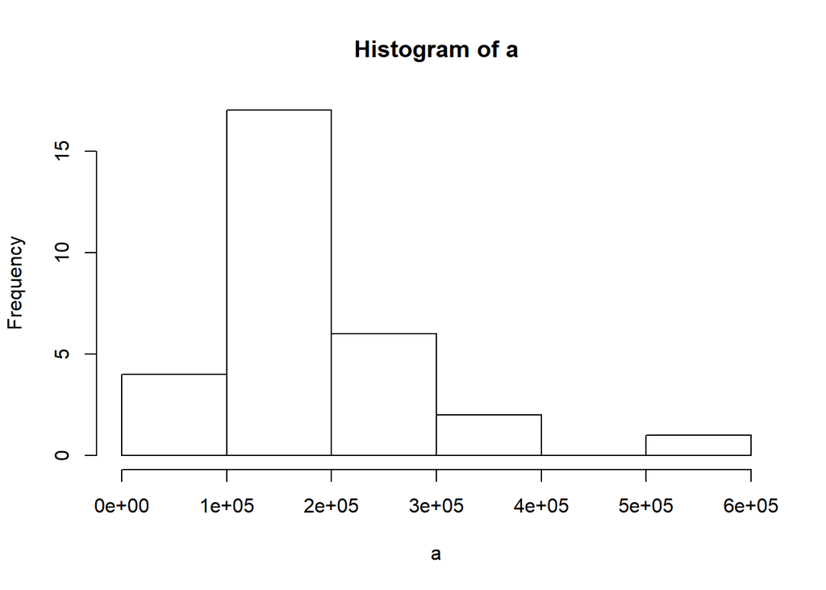

```r
sam9<-ames[ames$Yr.Sold == 2009,]
View(sam9)
data1<-sam9[sam9$Mo.Sold == c(1,2,3),]
data2<-sam9[sam9$Mo.Sold == c(4.5,6),]
data3<-sam9[sam9$Mo.Sold == c(7,8,9),]
data4<-sam9[sam9$Mo.Sold == c(10,11,12),]
a<-data1$SalePrice
hist(a)
```

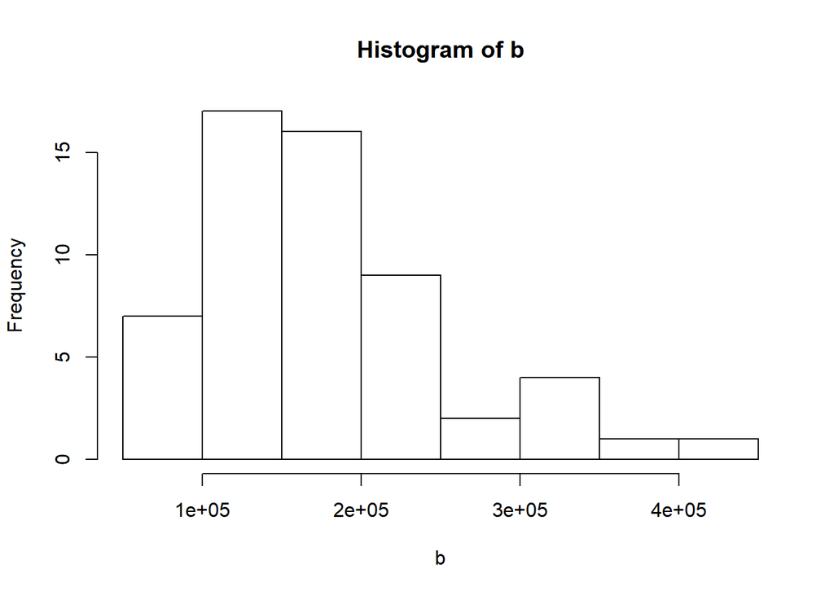

```r
b<-data2$SalePrice
hist(b)
```

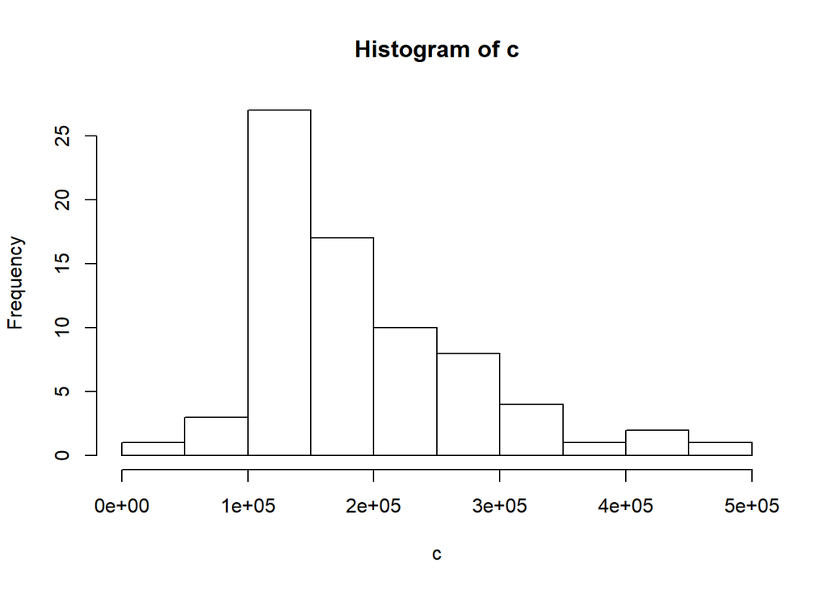

```r
c<-data3$SalePrice
hist(c)
```

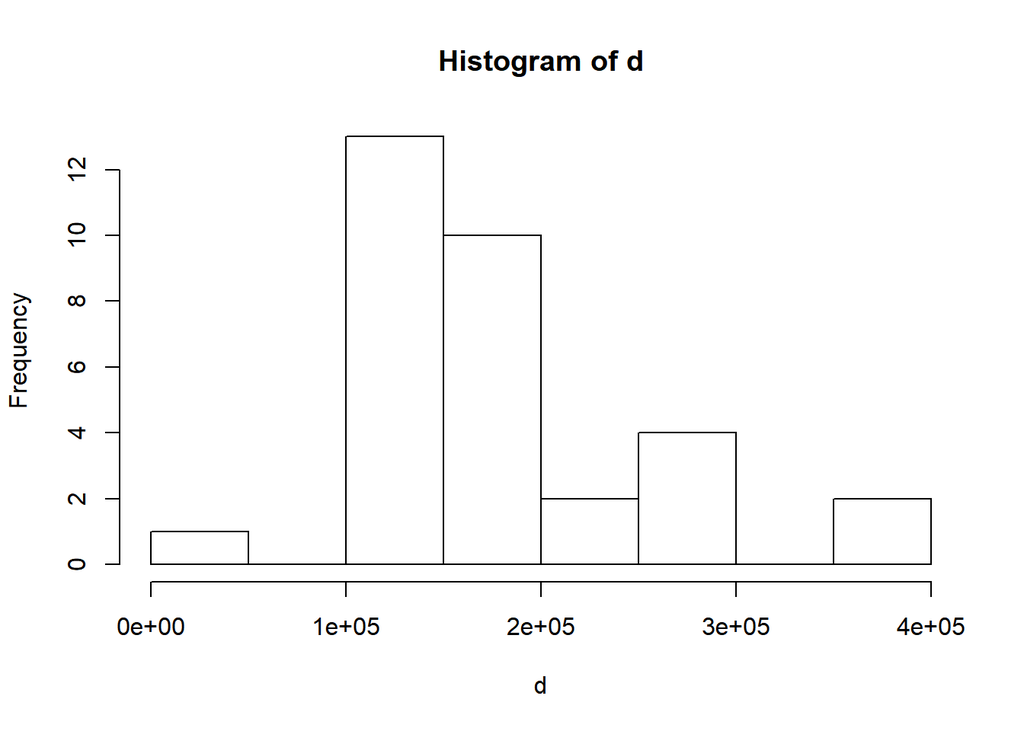

```r
d<-data4$SalePrice
hist(d)
```

대체적으로 right-skewed한 모습을 갖고있다. 분기별 분포의 큰 변화는 없다.

##예제7 확률변수 X를 주사위를 n번 던져 1의 눈이 나온 횟수라고 하자. 이 때, 다음의 확률을 구하여라. 7-1. 이항분포 하에서 (1) 10 번을 던져 1의 눈이 3번 이하로 나올 확률과 (2) 100번 던져 1의 눈이 30번 이하로 나올 확률을 구해보자.

```r
pbinom(3,10,1/6)
```

```
## [1] 0.9302722
```

```r
pbinom(30,100,1/6)
```

```
## [1] 0.9997042
```

7-2. 7-1.의 (1)과 (2)에서의 확률을 정규분포 하에서 구해보고, 7-1.의 값과 비교해보자.

```r
pnorm(3.5,5/3,sqrt(25/18))
```

```
## [1] 0.9401025
```

```r
pnorm(30.5,50/3,sqrt(250/18))
```

```
## [1] 0.9998971
```

표본의 크기가 클수록 이항분포에서 구한 값과 정규분포하에서 구한 값이 더 비슷하다. 그러므로 표본의 크기가가 클수록 이항분포가 정규분포에 근사함을 알 수 있었다.

##예제8 위와 같은 두 가지 선형 모형이 있다고 가정하자. 두 모형 모두𝑥∼𝑁(0,1)이라고 할 때, 각각의 모형을 따르는 100개의 자료를 만들고, 산점도를 만들어 비교해보자.

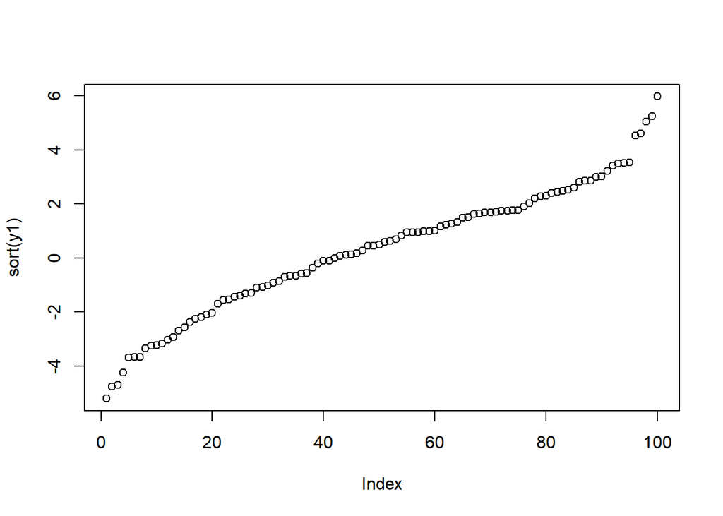

```r
x<-rnorm(100,0,1)
e1<-rnorm(100,0,1)
e2<-rnorm(100,0,50)
y1<- 0.5+2*x+e1
y2<- 0.5+2*x+e2
plot(sort(y1))
```

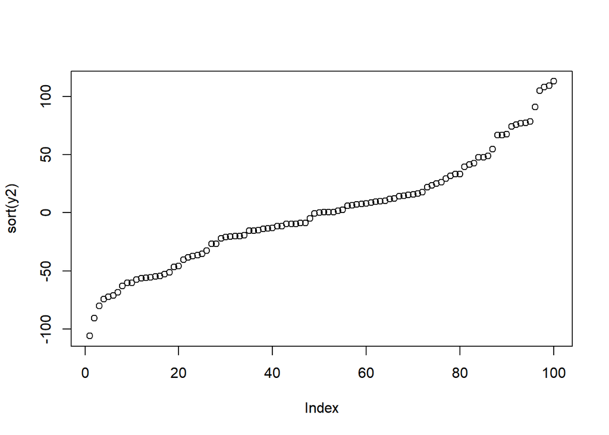

```r
plot(sort(y2))
```

y1에 비해 y2가 더 넓은 분산을 갖고있다.

##예제9 표본의 크기가 10인 자료𝑥1,…𝑥10이 정규분포𝑁(100,7^2)으로부터의 랜덤표본이라고 하자. 다음과 같은 식이 성립함을 보이고자 한다. (𝑆2은 표본 분산) (𝑛−1)𝑆2 𝜎2 =∑𝑛𝑖=1(𝑥𝑖−𝑥)̄2 𝜎2 ∼𝜒2(𝑛−1) 모집단 정규분포를 1000개 생성하여 위의 다음과 같은 결과를 보여라. 힌트: R에서의 var()함수는 표본분산을 구하는 함수이다.

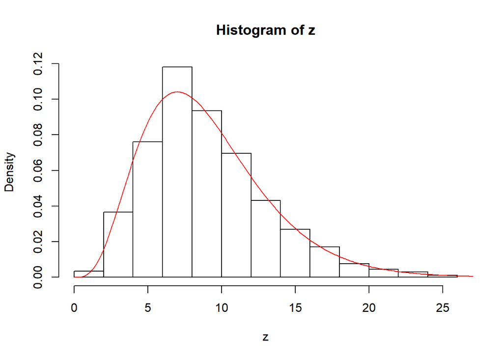

```r
n=10
z<-c()  #정규분포를 1000개 생성해 나온 좌변의 값에 대한 히스토그램
for (o in 1:1000)
  { x<-rnorm(10,100,7); z[o]<-(n-1)*var(x)/49 }
hist(z, probability=T)

y<-seq(0, 30, 0.1) #우변의 카이제곱분포
fy<-dchisq(y,n-1)
lines(y, fy, col="red")
```

##예제 10 X가 이항분포𝐵(7,0.3)을 따른다고 하자. 균등분포𝑈(0,1)에서 랜덤 표본을 생성해 이항변수(Binomial)를 만들고, 이 과정을 100000번 반복해라. 그리고𝑃(𝑋=2)를 구해 다음의 값과 비교해보자. (이때, rbinom() 함수는 이용하지 말 것) 힌트: Bernoulli(p)변수는runif()함수로생성가능하고, Binomial(p,n)변수는Bernoulli(p)변수의 합으로 생각할 수 있다. dbinom(2,7,0.3) ## [1] 0.3176523

```r
X<-c()
for (i in 1:100000) {
p <- 0.3; n <- 7; U <- runif(n, min = 0, max = 1);
X[i] <- sum(U < p)  }
sum(X==2)/100000
```

```
## [1] 0.31898
```

dbinom(2,7,0.3)과 매우 근사한 값이 나온다.